# Low Cost Carrier Flight Opportunities

Can be viewed online at https://isaiahvk.github.io/

## Intro

Recently, Spirit Airlines has been struggling to stay afloat, filing for bankruptcy twice in the past year. Ultra-low-cost-carriers (ULCCs) like Spirit operate on a point to point network, offering nonstop routes that the legacy airlines (Delta, American, and United) are unable or unwilling to compete with.

After completion of this project, Spirit Airlines has ceased operations, further showcasing the need for ULCCs to optimize routes as well as possible. Hopefully data can keep the ULCC business model alive for other carriers.

For background on the ULCC business model, check out [this article](https://www.sciencedirect.com/science/article/abs/pii/S0969699716303969) in the Journal of Air Transport Management.

## Goal

For my project, I plan to analyze flight bookings and economic conditions to determine which routes could potentially save struggling low cost carriers like Spirit.

## Data

- **Bureau of Transportation Statistics (BTS):** The BTS has a robust dataset of commerical airlines itineraries, including pricing, origin and destination, stops, and more. This data is free to access and includes a 10% sample of the data for that quarter. A full breakdown of the data can be found [here](https://transtats.bts.gov/).
- **OpenFlights:** This dataset provides geographic coordinates (latitude and longitude) for almost every airport globally. This allows us to map airport IATA codes to precise locations for weather querying. Learn more [here](https://openflights.org/data.html).
- **Open-Meteo:** A free, open-source historical weather API. By passing in the coordinates from OpenFlights, we fetch daily historical temperatures to calculate quarterly climate averages for origin and destination airports. Explore the API [here](https://open-meteo.com/).

```python
# Imports
import pandas as pd
import numpy as np
import matplotlib.pyplot as plt
import seaborn as sns
import requests
import zipfile
import io
import os
from google.colab import drive
```

```python
# Mount to Google Drive
drive.mount('/content/drive')
project_path = "../content/drive/MyDrive/Tulane/DataScience"
if os.path.isdir(project_path):
    print(f"Directory exists: {project_path}")
    print("Found files:", os.listdir(project_path))
else:
    print(f"Error: The directory does not exist at {project_path}")
```

```
Directory exists: ../content/drive/MyDrive/Tulane/DataScience
Found files: ['db1b_market_2025q1.parquet', 'db1b_coupon_2025q1.parquet', 'Data Science Exam 2 Cheat Sheet.gdoc', 'db1b_market_2025q2.parquet', 'db1b_coupon_2025q2.parquet', 'index.html', 'db1b_market_2024q1.parquet', 'db1b_coupon_2024q1.parquet', 'db1b_market_2024q2.parquet', 'db1b_coupon_2024q2.pa…
```

## Methodology for Importing the Data

The BTS has publicly available zip files with csv files inside. The first time we use data from a specific year and quarter, we must download it. After this initial download, data is stored to a parquet file in Google Drive for quicker loading.

```python
# @title Downloading the Data

def download_and_save_bts(year, quarter):
    # We have two tables of use from BTS
    tables = {
        "Market": f"https://transtats.bts.gov/PREZIP/Origin_and_Destination_Survey_DB1BMarket_{year}_{quarter}.zip",
        "Coupon": f"https://transtats.bts.gov/PREZIP/Origin_and_Destination_Survey_DB1BCoupon_{year}_{quarter}.zip"
    }

    for name, url in tables.items():
        filename = os.path.join(project_path, f"db1b_{name.lower()}_{year}q{quarter}.parquet")

        # Check if we already have the parquet file to skip the download
        if os.path.exists(filename):
            print(f"File {filename} already exists. Skipping download.")
            continue

        print(f"Downloading {name} data for {year} Q{quarter}...")
        response = requests.get(url)

        if response.status_code == 200:
            with zipfile.ZipFile(io.BytesIO(response.content)) as z:
                csv_file = [f for f in z.namelist() if f.endswith('.csv')][0]
                with z.open(csv_file) as f:

                    df = pd.read_csv(f, low_memory=False)

                    # Save as Parquet
                    df.to_parquet(filename, index=False)
                    print(f"Saved {name} to {filename}")
        else:
            print(f"Failed to download {name}.")
```

```python
# Download data for 2025 Q1
download_and_save_bts(2025, 1)
```

```
File ../content/drive/MyDrive/Tulane/DataScience/db1b_market_2025q1.parquet already exists. Skipping download.
File ../content/drive/MyDrive/Tulane/DataScience/db1b_coupon_2025q1.parquet already exists. Skipping download.
```

```python
# Load 2025 Q1 Data
df_market = pd.read_parquet(os.path.join(project_path, 'db1b_market_2025q1.parquet'))
df_coupon = pd.read_parquet(os.path.join(project_path, 'db1b_coupon_2025q1.parquet'))
```

## Preparing the Main Dataframe

Once data is downloaded and imported, it must be merged onto a single table. This is done by joining on the itinerary ID with an inner join. Before joining, the columns we need are selected to avoid issues with using too much memory.

These are the important variables that we will be using:

```python
# Creating a figure to explain important variables that will be used.
figure_data = {
    "Variable": [
        "ItinID", "MktFare", "Origin", "Dest",
        "OpCarrier", "Passengers", "MktMilesFlown"
    ],
    "Meaning": [
        "Itinerary ID",
        "Fare paid for each ticket",
        "Airport code where the itinerary begins",
        "Airport code where the itinerary ends",
        "Operating carrier (e.g., NK for Spirit)",
        "Number of passengers on the reservation",
        "Total distance flown for the itinerary"
    ]
}
figure = pd.DataFrame(figure_data)
figure.style.hide(axis='index')
```

| Variable | Meaning |
| --- | --- |
| ItinID | Itinerary ID |
| MktFare | Fare paid for each ticket |
| Origin | Airport code where the itinerary begins |
| Dest | Airport code where the itinerary ends |
| OpCarrier | Operating carrier (e.g., NK for Spirit) |
| Passengers | Number of passengers on the reservation |
| MktMilesFlown | Total distance flown for the itinerary |

```python
# Merge Tables and Select Important Columns

# It is important to only use columns we need to avoid using too much RAM.
# The market table has pricing and distance data.
market_cols = ["ItinID", "MktFare", "Origin", "Dest", "OpCarrier", "Passengers", "MktMilesFlown"]
# The coupon table is only to get layover information.
coupon_cols = ["ItinID", "Break"]
# Selecting the columns we want from each table
df_market = df_market[market_cols]
df_coupon = df_coupon[coupon_cols]

# If an ItinID has more than 1 row in the coupon table, it has a layover (1 = Connecting, 0 = Nonstop).
coupon_agg = df_coupon.groupby('ItinID').size().reset_index(name='Legs')
coupon_agg['Break'] = (coupon_agg['Legs'] > 1).astype(int)

# Inner join on itinerary ID
df_combined = df_market.merge(coupon_agg[['ItinID', 'Break']], on="ItinID", how="inner")
display(df_combined.head())
```

|  | ItinID | MktFare | Origin | Dest | OpCarrier | Passengers | MktMilesFlown | Break |
| --- | --- | --- | --- | --- | --- | --- | --- | --- |
| 0 | 202511660219 | 351.5 | SAN | ATL | DL | 1.0 | 1892.0 | 1 |
| 1 | 202511660220 | 352.0 | ATL | SAN | DL | 2.0 | 1892.0 | 1 |
| 2 | 202511660220 | 352.0 | SAN | ATL | DL | 2.0 | 1892.0 | 1 |
| 3 | 202511660221 | 352.5 | ATL | SAN | DL | 1.0 | 1892.0 | 1 |
| 4 | 202511660221 | 352.5 | SAN | ATL | DL | 1.0 | 1892.0 | 1 |

```python
# Break is 1 if connecting, 0 if nonstop.

df_combined["Break"].unique()
```

```
array([1, 0])
```

```python
# Check the breakdown of nonstop vs connecting flights

df_combined["Break"].value_counts()
```

| Break | count |
| --- | --- |
| 1 | 6481245 |
| 0 | 815783 |

**dtype:** int64

```python
# All dtypes are what we expect.

df_combined.dtypes
```

|  | 0 |
| --- | --- |
| ItinID | int64 |
| MktFare | float64 |
| Origin | object |
| Dest | object |
| OpCarrier | object |
| Passengers | float64 |
| MktMilesFlown | float64 |
| Break | int64 |

**dtype:** object

## Missing Data

Before analysis, we must check to see if there is any missing data in our dataset.

```python
# Check for missing values in the combined dataframe
missing_data = df_combined.isnull().sum()
missing_percentage = (missing_data / len(df_combined)) * 100

missing_df = pd.DataFrame({
    'Missing Values': missing_data,
    'Percentage (%)': missing_percentage
})

print("--- Missing Data Analysis ---")
display(missing_df.sort_values(by='Missing Values', ascending=False))
```

```
--- Missing Data Analysis ---
```

|  | Missing Values | Percentage (%) |
| --- | --- | --- |
| ItinID | 0 | 0.0 |
| MktFare | 0 | 0.0 |
| Origin | 0 | 0.0 |
| Dest | 0 | 0.0 |
| OpCarrier | 0 | 0.0 |
| Passengers | 0 | 0.0 |
| MktMilesFlown | 0 | 0.0 |
| Break | 0 | 0.0 |

## No Missing Data!

It seems the BTS has a well maintained database and does not have any missing data. Lets move onto the analysis.

## Why are nonstop flights important?

Nonstop flights, if adequate demand is met, are beneficial for all parties. Flying passengers on a single plane traveling less overall miles is more cost-effective for the airline, if the demand exists. It is also much more convenient from a customer perspective. Nonstop flights are shorter, and there is no worry about missing a connection.

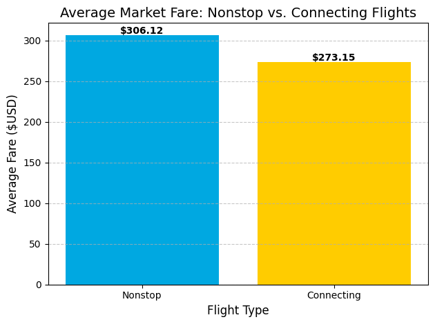

```python
# Visualization: Average Fares for Nonstop vs. Connecting Flights

# 1. Calculate the average fare for each category
fare_comparison = df_combined.groupby('Break')['MktFare'].mean()

# 2. Create the bar chart
plt.bar(['Nonstop', 'Connecting'], fare_comparison.values, color=['#00a8e1', '#ffcc00'])

# 3. Add titles and labels
plt.title('Average Market Fare: Nonstop vs. Connecting Flights', fontsize=14)
plt.xlabel('Flight Type', fontsize=12)
plt.ylabel('Average Fare ($USD)', fontsize=12)

# 4. Add data labels on top of the bars for precision
for i, value in enumerate(fare_comparison.values):
    plt.text(i, value + 2, f'${value:.2f}', ha='center', fontweight='bold')

# 5. Improve visual style
plt.grid(axis='y', linestyle='--', alpha=0.7)
plt.tight_layout()
```

## Misleading Insight

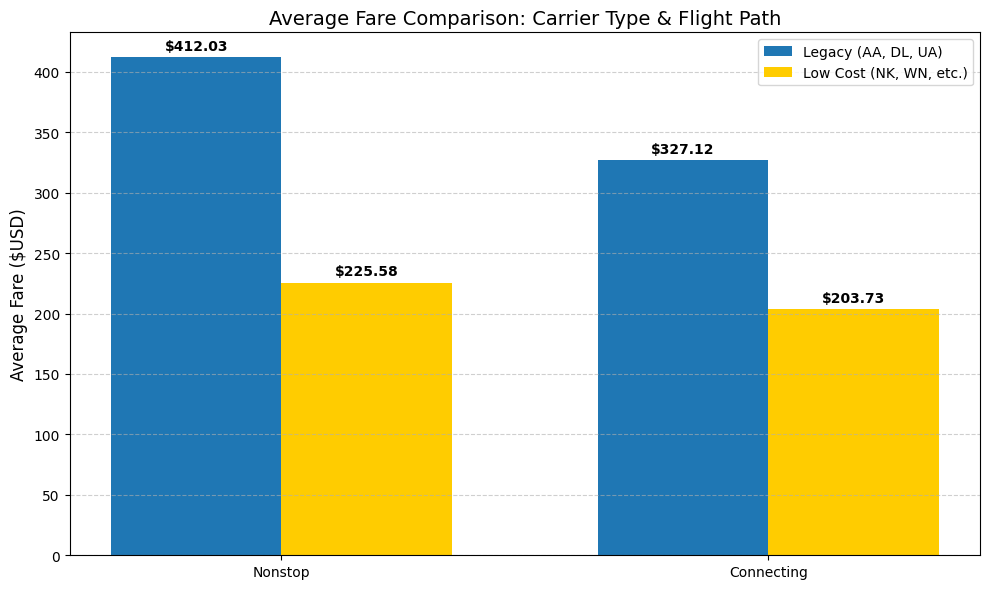

```python
# Define the carrier groups
legacy_carriers = ['AA', 'DL', 'UA']
lcc_carriers = ['NK', 'WN', 'B6', 'F9', 'G4', 'AS'] # Spirit, Southwest, JetBlue, Frontier, Allegiant, Alaska

def get_carrier_type(carrier):
    if carrier in legacy_carriers:
        return 'Legacy'
    elif carrier in lcc_carriers:
        return 'Low Cost'
    else:
        return 'Other'

# Apply the categorization
df_combined['CarrierType'] = df_combined['OpCarrier'].apply(get_carrier_type)

# Filter for the main comparison (excluding 'Other')
df_filtered = df_combined[df_combined['CarrierType'] != 'Other']

# 1. Calculate the average fare grouped by Break and Carrier Type
# Resulting structure: Rows = Break (0, 1), Columns = Carrier Type (Legacy, Low Cost)
fare_stats = df_filtered.groupby(['Break', 'CarrierType'])['MktFare'].mean().unstack()

# 2. Setup Plotting Variables
labels = ['Nonstop', 'Connecting']
legacy_means = fare_stats['Legacy']
lcc_means = fare_stats['Low Cost']

x = np.arange(len(labels))  # label locations
width = 0.35  # width of the bars

# 3. Create the figure and bars
fig, ax = plt.subplots(figsize=(10, 6))
rects1 = ax.bar(x - width/2, legacy_means, width, label='Legacy (AA, DL, UA)', color='#1f77b4') # Blue
rects2 = ax.bar(x + width/2, lcc_means, width, label='Low Cost (NK, WN, etc.)', color='#ffcc00') # Yellow

# 4. Add labels, title and axes ticks
ax.set_ylabel('Average Fare ($USD)', fontsize=12)
ax.set_title('Average Fare Comparison: Carrier Type & Flight Path', fontsize=14)
ax.set_xticks(x)
ax.set_xticklabels(labels)
ax.legend()

# 5. Add data labels on top of each bar
def autolabel(rects):
    for rect in rects:
        height = rect.get_height()
        ax.annotate(f'${height:.2f}',
                    xy=(rect.get_x() + rect.get_width() / 2, height),
                    xytext=(0, 3),  # 3 points vertical offset
                    textcoords="offset points",
                    ha='center', va='bottom', fontweight='bold')

autolabel(rects1)
autolabel(rects2)

plt.grid(axis='y', linestyle='--', alpha=0.6)
plt.tight_layout()
plt.show()
```

## Very different results

If you want to learn more about airline dynamic pricing, check out [this article](https://hls.harvard.edu/today/how-delta-airlines-and-other-companies-use-dynamic-pricing-to-determine-how-much-you-pay/) from Harvard Law Today.

## Lets examine the top connecting routes by revenue and passenger count

Now that we know why nonstops routes are more effective when the demand is present, lets look at what the top connecting routes are. This will give us insight into some of the most lucrative and underserved markets.

```python
# Processing the data for analysis

# 1. Filter for connecting flights only
df_connecting = df_combined[df_combined['Break'] == 1].copy()

# 2. Create a 'Route' identifier (e.g., "MSY-LGA")
df_connecting['Route'] = df_connecting['Origin'] + "-" + df_connecting['Dest']

# 3. Calculate estimated revenue for the sample
df_connecting['EstimatedRevenue'] = df_connecting['MktFare'] * df_connecting['Passengers']

# 4. Group by Route
route_stats = df_connecting.groupby('Route').agg({
    'Passengers': 'sum',
    'EstimatedRevenue': 'sum'
}).reset_index()
```

```python
# Top 10 Connecting Routes by Revenue
top_10_revenue = route_stats.sort_values(by='EstimatedRevenue', ascending=False).head(10)

print("--- Top 10 Connecting Routes by Revenue ---")
display(top_10_revenue[['Route', 'EstimatedRevenue', 'Passengers']])
```

```
--- Top 10 Connecting Routes by Revenue ---
```

|  | Route | EstimatedRevenue | Passengers |
| --- | --- | --- | --- |
| 34296 | LAX-JFK | 6589100.64 | 16519.0 |
| 32484 | JFK-LAX | 6534146.15 | 16418.0 |
| 57014 | SFO-EWR | 5206628.72 | 10743.0 |
| 20862 | EWR-SFO | 5185903.26 | 10707.0 |
| 32576 | JFK-SFO | 4058547.45 | 10822.0 |
| 57078 | SFO-JFK | 4036682.15 | 10769.0 |
| 34232 | LAX-EWR | 3531607.51 | 10427.0 |
| 20755 | EWR-LAX | 3526906.24 | 10354.0 |
| 38196 | MCO-DTW | 2806338.14 | 14313.0 |
| 18411 | DTW-MCO | 2763585.45 | 14179.0 |

```python
# Top 10 Connecting Routes by Passengers

top_10_passengers = route_stats.sort_values(by='Passengers', ascending=False).head(10)

print("\n--- Top 10 Connecting Routes by Passenger Count ---")
display(top_10_passengers[['Route', 'Passengers', 'EstimatedRevenue']])
```

```
--- Top 10 Connecting Routes by Passenger Count ---
```

|  | Route | Passengers | EstimatedRevenue |
| --- | --- | --- | --- |
| 38212 | MCO-EWR | 16732.0 | 2646424.56 |
| 20775 | EWR-MCO | 16690.0 | 2642695.75 |
| 34296 | LAX-JFK | 16519.0 | 6589100.64 |
| 32484 | JFK-LAX | 16418.0 | 6534146.15 |
| 16812 | DEN-PHX | 16040.0 | 2234932.34 |
| 48074 | PHX-DEN | 16033.0 | 2231111.18 |
| 45888 | ORD-LGA | 15241.0 | 2498349.08 |
| 35745 | LGA-ORD | 15235.0 | 2488612.49 |
| 47838 | PHL-MCO | 14676.0 | 2339644.63 |
| 38361 | MCO-PHL | 14645.0 | 2336825.67 |

## Lets see what the nonstop equivalent of these flights look like

Surely if these flights are the most popular connecting itineraries, other airlines have tried to make them nonstop itineraries too, right?

```python
# Processing the data for analysis

# 1. Filter for nonstop flights only
df_nonstop = df_combined[df_combined['Break'] == 0].copy()

# 2. Create a 'Route' identifier (e.g., "MSY-LGA")
df_nonstop['Route'] = df_nonstop['Origin'] + "-" + df_nonstop['Dest']

# 3. Calculate estimated revenue for the sample
df_nonstop['EstimatedRevenue'] = df_nonstop['MktFare'] * df_nonstop['Passengers']

# 4. Group by Route
route_stats_nonstop = df_nonstop.groupby('Route').agg({
    'Passengers': 'sum',
    'EstimatedRevenue': 'sum'
}).reset_index()
```

```python
# Find if any of the top 10 connecting routes exist anywhere in the nonstop dataset
matching_routes = route_stats_nonstop[route_stats_nonstop['Route'].isin(top_10_passengers['Route'])]

if matching_routes.empty:
    print("None of the top 10 connecting routes have nonstop counterparts in the dataset.")
else:
    print("Nonstop counterparts found for the top 10 connecting routes:")
    display(matching_routes.sort_values(by='Passengers', ascending=False))
```

```
Nonstop counterparts found for the top 10 connecting routes:
```

|  | Route | Passengers | EstimatedRevenue |
| --- | --- | --- | --- |
| 3561 | LAX-JFK | 10522.0 | 4835765.0 |
| 3293 | JFK-LAX | 10152.0 | 4454960.0 |
| 3927 | MCO-EWR | 6262.0 | 1095568.0 |
| 2267 | EWR-MCO | 6121.0 | 931057.0 |
| 4862 | ORD-LGA | 5950.0 | 1069666.0 |
| 3715 | LGA-ORD | 5812.0 | 1099486.0 |
| 3976 | MCO-PHL | 4308.0 | 745959.0 |
| 5273 | PHX-DEN | 4177.0 | 653013.0 |
| 1765 | DEN-PHX | 4125.0 | 638147.0 |
| 5201 | PHL-MCO | 3949.0 | 549114.0 |

## Top connecting routes DO have nonstop alternatives

```python
def get_route_data(start_year, start_q, end_year, end_q, routes):
    """
    Downloads (if necessary), loads, and filters BTS data for specific routes over a time period.

    Args:
        start_year (int): Starting year
        start_q (int): Starting quarter (1-4)
        end_year (int): Ending year
        end_q (int): Ending quarter (1-4)
        routes (list or str): A single route string (e.g., 'LAS-MCO') or list of routes.

    Returns:
        pd.DataFrame: A single dataframe containing the filtered itineraries.
    """
    if isinstance(routes, str):
        routes = [routes]

    all_filtered_data = []

    current_y, current_q = start_year, start_q

    while (current_y < end_year) or (current_y == end_year and current_q <= end_q):
        print(f"Processing {current_y} Q{current_q}...")

        # 1. Ensure data is downloaded
        download_and_save_bts(current_y, current_q)

        market_file = os.path.join(project_path, f'db1b_market_{current_y}q{current_q}.parquet')
        coupon_file = os.path.join(project_path, f'db1b_coupon_{current_y}q{current_q}.parquet')

        # 2. Load only necessary columns
        market_cols = ["ItinID", "MktFare", "Origin", "Dest", "OpCarrier", "Passengers", "MktMilesFlown"]
        coupon_cols = ["ItinID", "Break"]

        df_market = pd.read_parquet(market_file, columns=market_cols)
        df_coupon = pd.read_parquet(coupon_file, columns=coupon_cols)

        # Create Route identifier
        df_market['Route'] = df_market['Origin'] + "-" + df_market['Dest']

        # 3. Filter immediately to save RAM
        df_market_filtered = df_market[df_market['Route'].isin(routes)]

        coupon_agg = df_coupon.groupby('ItinID').size().reset_index(name='Legs')
        coupon_agg['Break'] = (coupon_agg['Legs'] > 1).astype(int)

        # Merge with coupon data for layover info
        df_merged = df_market_filtered.merge(coupon_agg[['ItinID', 'Break']], on="ItinID", how="inner")

        # Keep track of time period
        df_merged['Year'] = current_y
        df_merged['Quarter'] = current_q

        all_filtered_data.append(df_merged)

        # Move to next quarter
        current_q += 1
        if current_q > 4:
            current_q = 1
            current_y += 1

    # Combine all filtered quarters
    if all_filtered_data:
        final_df = pd.concat(all_filtered_data, ignore_index=True)
        print("\nFinished processing all quarters.")
        return final_df
    else:
        print("\nNo data found for the specified routes.")
        return pd.DataFrame()
```

```python
routes_to_analyze = ["LAS-MCO", "MCO-LAS"]
df_long_term = get_route_data(2024, 1, 2025, 2, routes_to_analyze)

display(df_long_term.head())
```

```
Processing 2024 Q1...
File ../content/drive/MyDrive/Tulane/DataScience/db1b_market_2024q1.parquet already exists. Skipping download.
File ../content/drive/MyDrive/Tulane/DataScience/db1b_coupon_2024q1.parquet already exists. Skipping download.
Processing 2024 Q2...
File ../content/drive/MyDrive/Tulane/DataScience/db1b_market_2024q2.parquet already exists. Skipping download.
File ../content/drive/MyDrive/Tulane/DataScience/db1b_coupon_2024q2.parquet already exists. Skipping download.
Processing 2024 Q3...
File ../content/drive/MyDrive/Tulane/DataScience/db1b_market_2024q3.parquet already exists. Skipping download.
File ../content/drive/MyDrive/Tulane/DataScience/db1b_coupon_2024q3.parquet already exists. Skipping download.
Processing 2024 Q4...
File ../content/drive/MyDrive/Tulane/DataScience/db1b_market_2024q4.parquet already exists. Skipping download.
File ../content/drive/MyDrive/Tulane/DataScience/db1b_coupon_2024q4.parquet already exists. Skipping download.
Processing 2025 Q1...
File ../content/drive/MyDrive/Tulane/DataScience/db1b_market_2025q1.parquet already exists. Skipping download.
File ../content/drive/MyDrive/Tulane/DataScience/db1b_coupon_2025q1.parquet already exists. Skipping download.
Processing 2025 Q2...
File ../content/drive/MyDrive/Tulane/DataScience/db1b_market_2025q2.parquet already exists. Skipping download.
File ../content/drive/MyDrive/Tulane/DataScience/db1b_coupon_2025q2.parquet already exists. Skipping download.

Finished processing all quarters.
```

|  | ItinID | MktFare | Origin | Dest | OpCarrier | Passengers | MktMilesFlown | Route | Break | Year | Quarter |
| --- | --- | --- | --- | --- | --- | --- | --- | --- | --- | --- | --- |
| 0 | 202414850815 | 165.11 | LAS | MCO | WN | 1.0 | 2039.0 | LAS-MCO | 1 | 2024 | 1 |
| 1 | 202414888201 | 170.70 | LAS | MCO | WN | 1.0 | 2039.0 | LAS-MCO | 1 | 2024 | 1 |
| 2 | 202414943501 | 265.07 | MCO | LAS | WN | 1.0 | 2084.0 | MCO-LAS | 1 | 2024 | 1 |
| 3 | 202415673118 | 213.95 | MCO | LAS | WN | 1.0 | 2040.0 | MCO-LAS | 1 | 2024 | 1 |
| 4 | 202411181467 | 401.81 | MCO | LAS | AA | 1.0 | 2104.0 | MCO-LAS | 1 | 2024 | 1 |

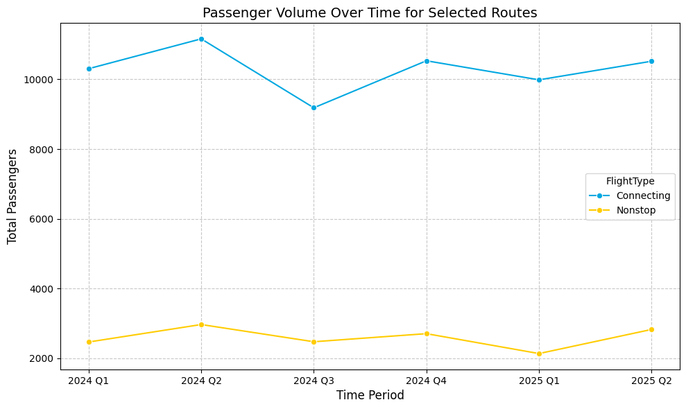

```python
# Create a string representation for time (Year-Quarter)
df_long_term['TimePeriod'] = df_long_term['Year'].astype(str) + " Q" + df_long_term['Quarter'].astype(str)

# Map break to string for a better legend
df_long_term['FlightType'] = df_long_term['Break'].map({0: 'Nonstop', 1: 'Connecting'})

# Aggregate passengers by TimePeriod and FlightType
time_series_data = df_long_term.groupby(['TimePeriod', 'FlightType'])['Passengers'].sum().reset_index()

# Plot the data
plt.figure(figsize=(10, 6))
sns.lineplot(data=time_series_data, x='TimePeriod', y='Passengers', hue='FlightType', marker='o', palette=['#00a8e1', '#ffcc00'])

plt.title('Passenger Volume Over Time for Selected Routes', fontsize=14)
plt.xlabel('Time Period', fontsize=12)
plt.ylabel('Total Passengers', fontsize=12)
plt.grid(True, linestyle='--', alpha=0.7)
plt.tight_layout()
plt.show()
```

## All of this begs the question...

Why are these connecting routes so popular when direct alternatives exist? To find out, lets do an analysis of fare price for each class of ticket.

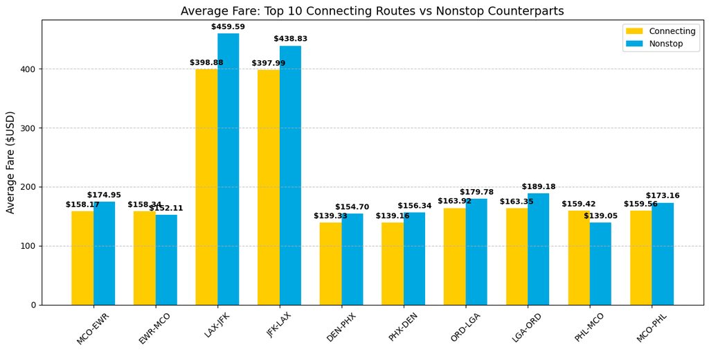

```python
# Calculate average fare for connecting routes
top_10_conn = top_10_passengers.copy()
top_10_conn['AvgFare_Connecting'] = top_10_conn['EstimatedRevenue'] / top_10_conn['Passengers']

# Calculate average fare for matching nonstop routes
match_nonstop = matching_routes.copy()
match_nonstop['AvgFare_Nonstop'] = match_nonstop['EstimatedRevenue'] / match_nonstop['Passengers']

# Merge data for comparison
fare_comp_routes = pd.merge(top_10_conn[['Route', 'AvgFare_Connecting']],
                            match_nonstop[['Route', 'AvgFare_Nonstop']],
                            on='Route', how='inner')

# Plot the data
labels = fare_comp_routes['Route']
connecting_fares = fare_comp_routes['AvgFare_Connecting']
nonstop_fares = fare_comp_routes['AvgFare_Nonstop']

x = np.arange(len(labels))
width = 0.35

fig, ax = plt.subplots(figsize=(12, 6))
rects1 = ax.bar(x - width/2, connecting_fares, width, label='Connecting', color='#ffcc00')
rects2 = ax.bar(x + width/2, nonstop_fares, width, label='Nonstop', color='#00a8e1')

ax.set_ylabel('Average Fare ($USD)', fontsize=12)
ax.set_title('Average Fare: Top 10 Connecting Routes vs Nonstop Counterparts', fontsize=14)
ax.set_xticks(x)
ax.set_xticklabels(labels, rotation=45)
ax.legend()

# Add data labels
def autolabel_bars(rects):
    for rect in rects:
        height = rect.get_height()
        ax.annotate(f'${height:.2f}',
                    xy=(rect.get_x() + rect.get_width() / 2, height),
                    xytext=(0, 3),
                    textcoords="offset points",
                    ha='center', va='bottom', fontsize=9, fontweight='bold')

autolabel_bars(rects1)
autolabel_bars(rects2)

plt.grid(axis='y', linestyle='--', alpha=0.7)
plt.tight_layout()
plt.show()
```

## The story gets even stranger

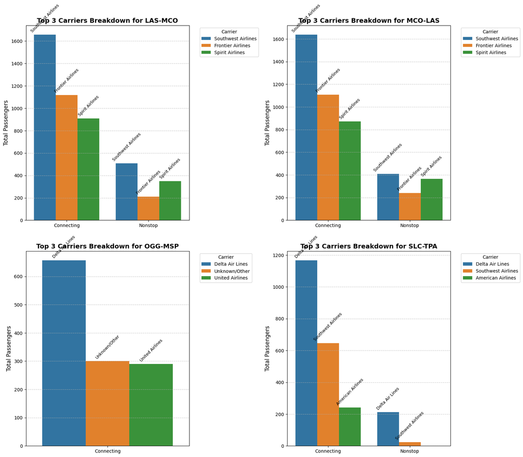

```python
# Define the specific routes we want to analyze
target_routes = ['LAS-MCO', 'MCO-LAS', 'OGG-MSP', 'SLC-TPA']

# Combine nonstop and connecting dataframes to get a unified view
df_conn_target = df_connecting[df_connecting['Route'].isin(target_routes)]
df_nonstop_target = df_nonstop[df_nonstop['Route'].isin(target_routes)]

df_target_combined = pd.concat([df_conn_target, df_nonstop_target])
df_target_combined['FlightType'] = df_target_combined['Break'].map({0: 'Nonstop', 1: 'Connecting'})

# Carrier name mapping
carrier_mapping = {
    'AA': 'American Airlines',
    'DL': 'Delta Air Lines',
    'UA': 'United Airlines',
    'WN': 'Southwest Airlines',
    'NK': 'Spirit Airlines',
    'B6': 'JetBlue Airways',
    'AS': 'Alaska Airlines',
    'F9': 'Frontier Airlines',
    'G4': 'Allegiant Air',
    'HA': 'Hawaiian Airlines',
    'SY': 'Sun Country Airlines',
    '99': 'Unknown/Other'
}
df_target_combined['CarrierName'] = df_target_combined['OpCarrier'].map(lambda x: carrier_mapping.get(str(x), str(x)))

# Group by Route, Flight Type, and Carrier to get passenger sums
carrier_breakdown = df_target_combined.groupby(['Route', 'FlightType', 'CarrierName'])['Passengers'].sum().reset_index()

# Keep only top 3 carriers per Route and FlightType
top_carriers = carrier_breakdown.sort_values(['Route', 'FlightType', 'Passengers'], ascending=[True, True, False])
top_carriers = top_carriers.groupby(['Route', 'FlightType']).head(3)

# Create a 2x2 grid of subplots for the 4 routes
fig, axes = plt.subplots(2, 2, figsize=(16, 14))
axes = axes.flatten()

for i, route in enumerate(target_routes):
    # Filter data for the specific route
    route_data = top_carriers[top_carriers['Route'] == route]

    # Create a barplot with hue as the Operating Carrier
    sns.barplot(data=route_data, x='FlightType', y='Passengers', hue='CarrierName', ax=axes[i], palette='tab10')

    # Extract handles and labels from the legend to get the correct carrier names
    handles, labels_list = axes[i].get_legend_handles_labels()

    # Add carrier names above the bars
    for container, carrier_name in zip(axes[i].containers, labels_list):
        # Only place labels on bars that have a height > 0
        labels = [carrier_name if rect.get_height() > 0 else "" for rect in container]
        axes[i].bar_label(container, labels=labels, padding=3, rotation=45, fontsize=9)

    axes[i].set_title(f'Top 3 Carriers Breakdown for {route}', fontsize=14, fontweight='bold')
    axes[i].set_ylabel('Total Passengers', fontsize=12)
    axes[i].set_xlabel('')
    axes[i].grid(axis='y', linestyle='--', alpha=0.7)
    axes[i].legend(title='Carrier', bbox_to_anchor=(1.05, 1), loc='upper left')

plt.tight_layout()
plt.show()
```

## Lets figure out what makes a good ULCC route

Lets examine routes where ULCCs specifically dominate. For this example, we will not be including Southwest, as they are shifting towards becoming a legacy carrier.

```python
# Define ULCCs excluding Southwest ('WN')
ulcc_carriers = ['NK', 'B6', 'F9', 'G4', 'AS']

# Filter the combined dataframe for these specific carriers
df_ulcc = df_combined[df_combined['OpCarrier'].isin(ulcc_carriers)].copy()

# Create a route identifier
df_ulcc['Route'] = df_ulcc['Origin'] + "-" + df_ulcc['Dest']

# Calculate Estimated Revenue
df_ulcc['EstimatedRevenue'] = df_ulcc['MktFare'] * df_ulcc['Passengers']

# Group by Route to get total passengers and revenue
ulcc_route_stats = df_ulcc.groupby('Route').agg({
    'Passengers': 'sum',
    'EstimatedRevenue': 'sum'
}).reset_index()

# Get the top 10 ULCC routes by passenger count
top_10_ulcc = ulcc_route_stats.sort_values(by='Passengers', ascending=False).head(10)

print("--- Top 10 ULCC Routes by Passengers (Excluding Southwest) ---")
display(top_10_ulcc)
```

```
--- Top 10 ULCC Routes by Passengers (Excluding Southwest) ---
```

|  | Route | Passengers | EstimatedRevenue |
| --- | --- | --- | --- |
| 3923 | MCO-BOS | 13109.0 | 2278469.07 |
| 844 | BOS-MCO | 12605.0 | 2029383.94 |
| 7048 | SJU-MCO | 12158.0 | 1766721.23 |
| 4016 | MCO-SJU | 12041.0 | 1615375.45 |
| 7042 | SJU-JFK | 10616.0 | 1908954.97 |
| 2401 | FLL-BOS | 10281.0 | 1682924.66 |
| 3183 | JFK-SJU | 10154.0 | 1653348.97 |
| 3946 | MCO-EWR | 10074.0 | 1266499.26 |
| 826 | BOS-FLL | 10070.0 | 1487808.87 |
| 2170 | EWR-MCO | 9797.0 | 1146393.19 |

## ULCCs Dominate in Warm Weather Leisure Travel

All flights in the top 10 either start or end at a vacation destination. Florida and Puerto Rico are especially popular. This makes sense, because business travelers often opt not to take ULCCs. Many companies prohibit flying on airlines like Spirit or Frontier for one reason or another. Lets do a similar analysis as we did on the top connecting itineraries and compare these ULCC dominated routes to their connecting counterparts.

```python
routes_to_analyze_ulcc = ["MCO-BOS", "BOS-MCO"]
# Fetch data using the helper function we defined earlier
df_ulcc_long_term = get_route_data(2024, 1, 2025, 2, routes_to_analyze_ulcc)

display(df_ulcc_long_term.head())
```

```
Processing 2024 Q1...
File ../content/drive/MyDrive/Tulane/DataScience/db1b_market_2024q1.parquet already exists. Skipping download.
File ../content/drive/MyDrive/Tulane/DataScience/db1b_coupon_2024q1.parquet already exists. Skipping download.
Processing 2024 Q2...
File ../content/drive/MyDrive/Tulane/DataScience/db1b_market_2024q2.parquet already exists. Skipping download.
File ../content/drive/MyDrive/Tulane/DataScience/db1b_coupon_2024q2.parquet already exists. Skipping download.
Processing 2024 Q3...
File ../content/drive/MyDrive/Tulane/DataScience/db1b_market_2024q3.parquet already exists. Skipping download.
File ../content/drive/MyDrive/Tulane/DataScience/db1b_coupon_2024q3.parquet already exists. Skipping download.
Processing 2024 Q4...
File ../content/drive/MyDrive/Tulane/DataScience/db1b_market_2024q4.parquet already exists. Skipping download.
File ../content/drive/MyDrive/Tulane/DataScience/db1b_coupon_2024q4.parquet already exists. Skipping download.
Processing 2025 Q1...
File ../content/drive/MyDrive/Tulane/DataScience/db1b_market_2025q1.parquet already exists. Skipping download.
File ../content/drive/MyDrive/Tulane/DataScience/db1b_coupon_2025q1.parquet already exists. Skipping download.
Processing 2025 Q2...
File ../content/drive/MyDrive/Tulane/DataScience/db1b_market_2025q2.parquet already exists. Skipping download.
File ../content/drive/MyDrive/Tulane/DataScience/db1b_coupon_2025q2.parquet already exists. Skipping download.

Finished processing all quarters.
```

|  | ItinID | MktFare | Origin | Dest | OpCarrier | Passengers | MktMilesFlown | Route | Break | Year | Quarter |
| --- | --- | --- | --- | --- | --- | --- | --- | --- | --- | --- | --- |
| 0 | 202414846443 | 5.0 | BOS | MCO | WN | 1.0 | 1558.0 | BOS-MCO | 1 | 2024 | 1 |
| 1 | 202414846444 | 118.0 | BOS | MCO | WN | 2.0 | 1558.0 | BOS-MCO | 1 | 2024 | 1 |
| 2 | 202414846445 | 123.0 | BOS | MCO | WN | 1.0 | 1558.0 | BOS-MCO | 1 | 2024 | 1 |
| 3 | 202414846446 | 160.5 | BOS | MCO | WN | 1.0 | 1558.0 | BOS-MCO | 1 | 2024 | 1 |
| 4 | 202414846446 | 160.5 | MCO | BOS | WN | 1.0 | 1558.0 | MCO-BOS | 1 | 2024 | 1 |

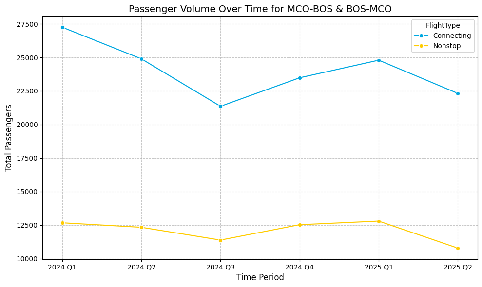

```python
# Create a string representation for time (Year-Quarter)
df_ulcc_long_term['TimePeriod'] = df_ulcc_long_term['Year'].astype(str) + " Q" + df_ulcc_long_term['Quarter'].astype(str)

# Map break to string for a better legend
df_ulcc_long_term['FlightType'] = df_ulcc_long_term['Break'].map({0: 'Nonstop', 1: 'Connecting'})

# Aggregate passengers by TimePeriod and FlightType
time_series_ulcc = df_ulcc_long_term.groupby(['TimePeriod', 'FlightType'])['Passengers'].sum().reset_index()

# Plot the data
plt.figure(figsize=(10, 6))
sns.lineplot(data=time_series_ulcc, x='TimePeriod', y='Passengers', hue='FlightType', marker='o', palette=['#00a8e1', '#ffcc00'])

plt.title('Passenger Volume Over Time for MCO-BOS & BOS-MCO', fontsize=14)
plt.xlabel('Time Period', fontsize=12)
plt.ylabel('Total Passengers', fontsize=12)
plt.grid(True, linestyle='--', alpha=0.7)
plt.tight_layout()
plt.show()
```

## Much more in line with expectations

```python
# 1. Load the OpenFlights Airport Database
# This dataset contains geographic coordinates for almost every airport
airports_url = "https://raw.githubusercontent.com/jpatokal/openflights/master/data/airports.dat"

# Define the columns based on the OpenFlights data dictionary
airport_cols = ['AirportID', 'Name', 'City', 'Country', 'IATA', 'ICAO', 'Latitude', 'Longitude', 'Altitude', 'Timezone', 'DST', 'TzDatabase', 'Type', 'Source']

df_airports = pd.read_csv(airports_url, names=airport_cols, na_values=['\\N'])

# Filter for relevant columns and drop rows without an IATA code
df_airports = df_airports[['IATA', 'Name', 'City', 'Latitude', 'Longitude']].dropna(subset=['IATA'])

# 2. Let's test it out by grabbing the unique airports from our top ULCC routes
unique_ulcc_airports = pd.concat([top_10_ulcc['Route'].str.split('-').str[0],
                                  top_10_ulcc['Route'].str.split('-').str[1]]).unique()

ulcc_airport_coords = df_airports[df_airports['IATA'].isin(unique_ulcc_airports)]

print("Coordinates for top ULCC route airports:")
display(ulcc_airport_coords.head(10))
```

```
Coordinates for top ULCC route airports:
```

|  | IATA | Name | City | Latitude | Longitude |
| --- | --- | --- | --- | --- | --- |
| 2745 | SJU | Luis Munoz Marin International Airport | San Juan | 18.439400 | -66.001801 |
| 3249 | BOS | General Edward Lawrence Logan International Ai... | Boston | 42.364300 | -71.005203 |
| 3295 | EWR | Newark Liberty International Airport | Newark | 40.692501 | -74.168701 |
| 3333 | FLL | Fort Lauderdale Hollywood International Airport | Fort Lauderdale | 26.072599 | -80.152702 |
| 3597 | JFK | John F Kennedy International Airport | New York | 40.639801 | -73.778900 |
| 3678 | MCO | Orlando International Airport | Orlando | 28.429399 | -81.308998 |

Now that we have the exact `Latitude` and `Longitude` for the airports, we can programmatically pass these coordinates into the Open-Meteo Historical Weather API to get average temperatures for any quarter!

```python
import time

def get_quarterly_temperature(lat, lon, year, quarter):
    """
    Fetches historical daily temperatures from Open-Meteo and returns the quarterly average.
    """
    # Define start and end dates for quarters
    quarter_dates = {
        1: ('01-01', '03-31'),
        2: ('04-01', '06-30'),
        3: ('07-01', '09-30'),
        4: ('10-01', '12-31')
    }

    start_date = f"{year}-{quarter_dates[quarter][0]}"
    end_date = f"{year}-{quarter_dates[quarter][1]}"

    # Open-Meteo Historical API endpoint
    url = "https://archive-api.open-meteo.com/v1/archive"
    params = {
        "latitude": lat,
        "longitude": lon,
        "start_date": start_date,
        "end_date": end_date,
        "daily": "temperature_2m_mean",
        "temperature_unit": "fahrenheit",
        "timezone": "auto"
    }

    try:
        response = requests.get(url, params=params)
        if response.status_code == 200:
            data = response.json()
            if 'daily' in data and 'temperature_2m_mean' in data['daily']:
                temps = data['daily']['temperature_2m_mean']
                # Filter out None values just in case
                valid_temps = [t for t in temps if t is not None]
                if valid_temps:
                    return sum(valid_temps) / len(valid_temps)
        else:
            print(f"API Error: {response.status_code}")
    except Exception as e:
        print(f"Request failed: {e}")

    return None

# Let's fetch temperatures for our top ULCC airports for 2024 Q1 to Q4
weather_data = []

print("Fetching weather data from Open-Meteo...")
for index, row in ulcc_airport_coords.iterrows():
    iata = row['IATA']
    lat = row['Latitude']
    lon = row['Longitude']

    for q in range(1, 5):
        avg_temp = get_quarterly_temperature(lat, lon, 2024, q)
        weather_data.append({
            'IATA': iata,
            'Year': 2024,
            'Quarter': q,
            'TimePeriod': f"2024 Q{q}",
            'Avg_Temp_F': round(avg_temp, 1) if avg_temp is not None else None
        })
        # Small delay to respect API rate limits
        time.sleep(0.25)

# Convert to DataFrame
df_weather = pd.DataFrame(weather_data)

print("Finished fetching weather data.")
display(df_weather.head(12))
```

```
Fetching weather data from Open-Meteo...
Finished fetching weather data.
```

|  | IATA | Year | Quarter | TimePeriod | Avg_Temp_F |
| --- | --- | --- | --- | --- | --- |
| 0 | SJU | 2024 | 1 | 2024 Q1 | 78.1 |
| 1 | SJU | 2024 | 2 | 2024 Q2 | 80.9 |
| 2 | SJU | 2024 | 3 | 2024 Q3 | 82.9 |
| 3 | SJU | 2024 | 4 | 2024 Q4 | 81.1 |
| 4 | BOS | 2024 | 1 | 2024 Q1 | 35.5 |
| 5 | BOS | 2024 | 2 | 2024 Q2 | 58.6 |
| 6 | BOS | 2024 | 3 | 2024 Q3 | 70.2 |
| 7 | BOS | 2024 | 4 | 2024 Q4 | 45.5 |
| 8 | EWR | 2024 | 1 | 2024 Q1 | 38.4 |
| 9 | EWR | 2024 | 2 | 2024 Q2 | 62.8 |
| 10 | EWR | 2024 | 3 | 2024 Q3 | 73.1 |
| 11 | EWR | 2024 | 4 | 2024 Q4 | 48.0 |

## Models!

Now that we have some good data to work with, we need to build models that help ULCCs predict which routes are worth taking on.

## Model 1: Route Profitability Prediction

Y = total revenue

X = quarterly weather averages, airport distance, pre-existing demand, competition (dummy variable), region of country (for both airports)

We can predict how profitable a route will be for a ULCC by the climate at the origin and destination airport, how far apart the airports are, and what the current demand looks like.

**Hypothesis:** Routes from cold states (especially in the winter) to routes in warm beach states will be most profitable as people want to escape the cold for a beach vacation.

## Model 2: Route Passenger Count

Y = Total passengers

X = quarterly weather averages, airport distance, pre-existing demand, competition (dummy variable), region of country (for both airports)

Predicting the amount of passengers is just as important as predicting revenue, because high passenger demand can in turn lead to the long-term ability to charge higher fares once market share is captured on a route.

### Data Preparation for Model 1

We need to aggregate the data at the route level to extract our features: pre-existing demand, competition (nonstop exists), distance, and regions. To train the model quickly without hitting API rate limits for thousands of airports, we will use a latitude-based proxy for historical temperature, while our final prediction function will fetch real data.

```python
import numpy as np
from sklearn.model_selection import train_test_split
from sklearn.linear_model import LinearRegression
from sklearn.metrics import mean_squared_error, r2_score
from sklearn.preprocessing import OneHotEncoder
from sklearn.compose import ColumnTransformer
from sklearn.pipeline import Pipeline

# 1. Calculate Estimated Revenue for the entire dataset
df_combined['EstimatedRevenue'] = df_combined['MktFare'] * df_combined['Passengers']

# 2. Aggregate Data by Route
print("Aggregating route data...")
route_group = df_combined.groupby(['Origin', 'Dest']).agg(
    Total_Passengers=('Passengers', 'sum'),
    Total_Revenue=('EstimatedRevenue', 'sum'),
    Nonstop_Exists=('Break', lambda x: 1 if 0 in x.values else 0)
).reset_index()

# 3. Haversine distance formula to calculate distance between airports
def haversine(lat1, lon1, lat2, lon2):
    R = 3958.8 # Earth radius in miles
    lat1, lon1, lat2, lon2 = map(np.radians, [lat1, lon1, lat2, lon2])
    dlat = lat2 - lat1
    dlon = lon2 - lon1
    a = np.sin(dlat/2)**2 + np.cos(lat1) * np.cos(lat2) * np.sin(dlon/2)**2
    c = 2 * np.arcsin(np.sqrt(a))
    return R * c

# Merge Origin coordinates
route_group = route_group.merge(df_airports[['IATA', 'Latitude', 'Longitude']], left_on='Origin', right_on='IATA', how='inner')
route_group.rename(columns={'Latitude': 'Orig_Lat', 'Longitude': 'Orig_Lon'}, inplace=True)
route_group.drop(columns=['IATA'], inplace=True)

# Merge Destination coordinates
route_group = route_group.merge(df_airports[['IATA', 'Latitude', 'Longitude']], left_on='Dest', right_on='IATA', how='inner')
route_group.rename(columns={'Latitude': 'Dest_Lat', 'Longitude': 'Dest_Lon'}, inplace=True)
route_group.drop(columns=['IATA'], inplace=True)

# Calculate Distance
route_group['Distance'] = haversine(route_group['Orig_Lat'], route_group['Orig_Lon'], route_group['Dest_Lat'], route_group['Dest_Lon'])

# 4. Map Regions based on roughly defined coordinate bounds
def get_region(lat, lon):
    if lon > -80 and lat > 39: return 'Northeast'
    elif -104 < lon <= -80 and lat > 36: return 'Midwest'
    elif lon > -104 and lat <= 39: return 'South'
    else: return 'West'

route_group['Orig_Region'] = route_group.apply(lambda row: get_region(row['Orig_Lat'], row['Orig_Lon']), axis=1)
route_group['Dest_Region'] = route_group.apply(lambda row: get_region(row['Dest_Lat'], row['Dest_Lon']), axis=1)

# 5. Create a temperature proxy for training to avoid API throttling
# This gives a rough estimate (warmer closer to equator)
route_group['Orig_Temp'] = 100 - (route_group['Orig_Lat'] * 1.2)
route_group['Dest_Temp'] = 100 - (route_group['Dest_Lat'] * 1.2)

display(route_group.head())
```

```
Aggregating route data...
```

|  | Origin | Dest | Total_Passengers | Total_Revenue | Nonstop_Exists | Orig_Lat | Orig_Lon | Dest_Lat | Dest_Lon | Distance | Orig_Region | Dest_Region | Orig_Temp | Dest_Temp |
| --- | --- | --- | --- | --- | --- | --- | --- | --- | --- | --- | --- | --- | --- | --- |
| 0 | ABE | ABI | 1.0 | 895.41 | 0 | 40.6521 | -75.440804 | 32.411301 | -99.681900 | 1455.179071 | Northeast | South | 51.21748 | 61.106439 |
| 1 | ABE | ABQ | 21.0 | 7099.52 | 0 | 40.6521 | -75.440804 | 35.040199 | -106.609001 | 1734.507037 | Northeast | West | 51.21748 | 57.951761 |
| 2 | ABE | ABY | 5.0 | 2052.50 | 0 | 40.6521 | -75.440804 | 31.535500 | -84.194504 | 796.346739 | Northeast | South | 51.21748 | 62.157401 |
| 3 | ABE | AEX | 3.0 | 979.50 | 0 | 40.6521 | -75.440804 | 31.327400 | -92.549797 | 1149.948901 | Northeast | South | 51.21748 | 62.407120 |
| 4 | ABE | AGS | 11.0 | 3792.00 | 0 | 40.6521 | -75.440804 | 33.369900 | -81.964500 | 618.219265 | Northeast | South | 51.21748 | 59.956120 |

### Training the Linear Regression Model

```python
# Prepare Features (X) and Target (y)
features = ['Orig_Temp', 'Dest_Temp', 'Distance', 'Total_Passengers', 'Nonstop_Exists', 'Orig_Region', 'Dest_Region']
X = route_group[features]
y = route_group['Total_Revenue']

# Preprocessing for categorical data (Regions)
categorical_features = ['Orig_Region', 'Dest_Region']
categorical_transformer = OneHotEncoder(handle_unknown='ignore')

preprocessor = ColumnTransformer(
    transformers=[
        ('cat', categorical_transformer, categorical_features)
    ], remainder='passthrough')

# Create Pipeline
lr_pipeline = Pipeline(steps=[
    ('preprocessor', preprocessor),
    ('regressor', LinearRegression())
])

# Train-test split
X_train, X_test, y_train, y_test = train_test_split(X, y, test_size=0.2, random_state=42)

# Train model
lr_pipeline.fit(X_train, y_train)

# Evaluate model
y_pred = lr_pipeline.predict(X_test)
print("--- Model 1: Route Profitability Performance ---")
print(f"RMSE: ${np.sqrt(mean_squared_error(y_test, y_pred)):,.2f}")
print(f"R^2 Score: {r2_score(y_test, y_pred):.4f}")
```

```
--- Model 1: Route Profitability Performance ---
RMSE: $66,120.97
R^2 Score: 0.8785
```

### Profitability Prediction Function

Pass in `['ORIGIN', 'DESTINATION', QUARTER]` and we will fetch the live Open-Meteo weather data, lookup the demand, and generate a prediction.

```python
def predict_profitability(origin_code, dest_code, quarter, year=2024):
    """
    Predicts the estimated revenue (profitability) for a route using the trained Linear Regression model.
    """
    # 1. Get airport info
    orig_info = df_airports[df_airports['IATA'] == origin_code]
    dest_info = df_airports[df_airports['IATA'] == dest_code]

    if orig_info.empty or dest_info.empty:
        return "Error: Airport code not found in OpenFlights dataset."

    orig_lat, orig_lon = orig_info.iloc[0]['Latitude'], orig_info.iloc[0]['Longitude']
    dest_lat, dest_lon = dest_info.iloc[0]['Latitude'], dest_info.iloc[0]['Longitude']

    # 2. Fetch actual weather
    print(f"Fetching weather for {origin_code} and {dest_code} for {year} Q{quarter}...")
    orig_temp = get_quarterly_temperature(orig_lat, orig_lon, year, quarter)
    dest_temp = get_quarterly_temperature(dest_lat, dest_lon, year, quarter)

    # Fallback to proxy if API fails
    if orig_temp is None: orig_temp = 100 - (orig_lat * 1.2)
    if dest_temp is None: dest_temp = 100 - (dest_lat * 1.2)

    # 3. Calculate distance
    dist = haversine(orig_lat, orig_lon, dest_lat, dest_lon)

    # 4. Get Regions
    orig_region = get_region(orig_lat, orig_lon)
    dest_region = get_region(dest_lat, dest_lon)

    # 5. Get Pre-existing Demand & Competition
    route_data = route_group[(route_group['Origin'] == origin_code) & (route_group['Dest'] == dest_code)]
    if not route_data.empty:
        demand = route_data.iloc[0]['Total_Passengers']
        competition = route_data.iloc[0]['Nonstop_Exists']
    else:
        demand = 0
        competition = 0

    # 6. Create feature dataframe
    feature_df = pd.DataFrame([{
        'Orig_Temp': orig_temp,
        'Dest_Temp': dest_temp,
        'Distance': dist,
        'Total_Passengers': demand,
        'Nonstop_Exists': competition,
        'Orig_Region': orig_region,
        'Dest_Region': dest_region
    }])

    # 7. Predict
    prediction = lr_pipeline.predict(feature_df)[0]

    print("\n" + "="*40)
    print(f"Route Prediction: {origin_code} -> {dest_code} (Q{quarter})")
    print("-"*40)
    print(f"Distance: {dist:.1f} miles")
    print(f"Origin ({orig_region}): {orig_temp:.1f}°F")
    print(f"Destination ({dest_region}): {dest_temp:.1f}°F")
    print(f"Current Demand: {demand:,.0f} passengers")
    print(f"Nonstop Competition: {'Yes' if competition else 'No'}")
    print("="*40)
    print(f"Predicted Revenue/Profitability: ${prediction:,.2f}")
    print("="*40)

    return prediction
```

```python
# Let's test it on a cold-to-warm route in Q1!
predict_profitability('ALB', 'TPA', 1);
predict_profitability('ALB', 'TPA', 2);
predict_profitability('ALB', 'TPA', 3);
predict_profitability('ALB', 'TPA', 4);
```

```
Fetching weather for ALB and TPA for 2024 Q1...

========================================
Route Prediction: ALB -> TPA (Q1)
----------------------------------------
Distance: 1131.5 miles
Origin (Northeast): 34.0°F
Destination (South): 63.5°F
Current Demand: 1,342 passengers
Nonstop Competition: Yes
========================================
Predicted Revenue/Profitability: $287,504.12
========================================
Fetching weather for ALB and TPA for 2024 Q2...

========================================
Route Prediction: ALB -> TPA (Q2)
----------------------------------------
Distance: 1131.5 miles
Origin (Northeast): 60.7°F
Destination (South): 78.9°F
Current Demand: 1,342 passengers
Nonstop Competition: Yes
========================================
Predicted Revenue/Profitability: $281,633.76
========================================
Fetching weather for ALB and TPA for 2024 Q3...

========================================
Route Prediction: ALB -> TPA (Q3)
----------------------------------------
Distance: 1131.5 miles
Origin (Northeast): 70.6°F
Destination (South): 81.7°F
Current Demand: 1,342 passengers
Nonstop Competition: Yes
========================================
Predicted Revenue/Profitability: $280,000.40
========================================
Fetching weather for ALB and TPA for 2024 Q4...

========================================
Route Prediction: ALB -> TPA (Q4)
----------------------------------------
Distance: 1131.5 miles
Origin (Northeast): 42.2°F
Destination (South): 69.2°F
Current Demand: 1,342 passengers
Nonstop Competition: Yes
========================================
Predicted Revenue/Profitability: $285,516.79
========================================
```

### Variable Relationships

Let's look at a correlation heatmap to understand how our features relate to each other and to our target variable, Total Revenue.

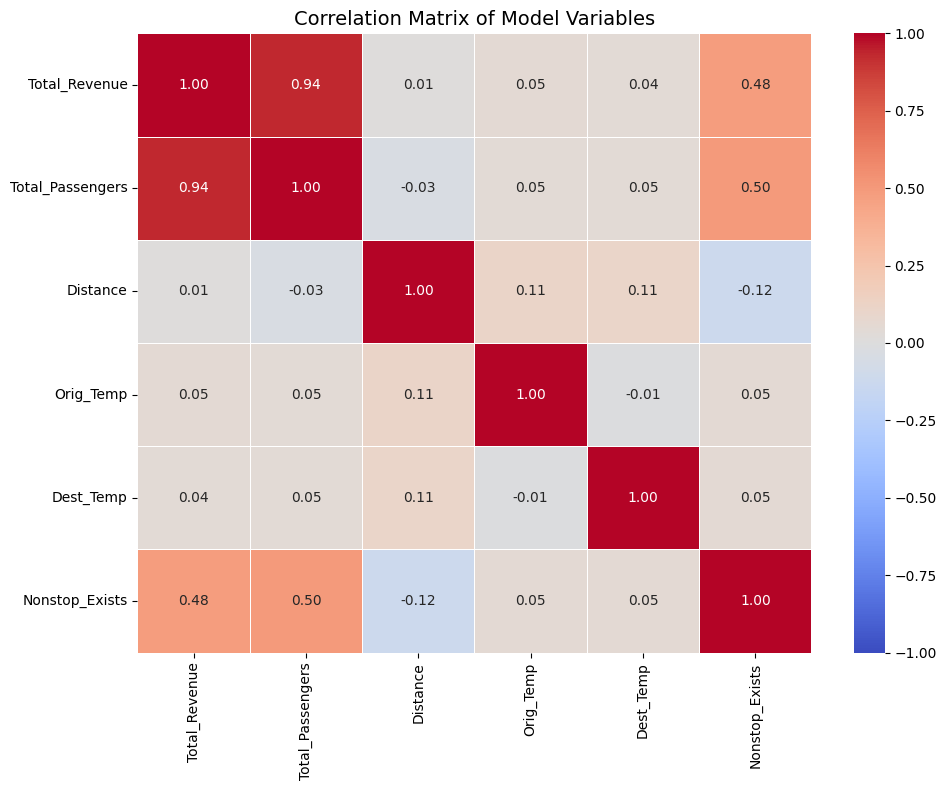

```python
# Select the numerical variables used in the model, plus the target
corr_cols = ['Total_Revenue', 'Total_Passengers', 'Distance', 'Orig_Temp', 'Dest_Temp', 'Nonstop_Exists']
corr_matrix = route_group[corr_cols].corr()

# Create the heatmap
plt.figure(figsize=(10, 8))
sns.heatmap(corr_matrix, annot=True, cmap='coolwarm', fmt=".2f", linewidths=0.5, vmin=-1, vmax=1)
plt.title('Correlation Matrix of Model Variables', fontsize=14)
plt.tight_layout()
plt.show()
```

### Training Model 2: Expected Passenger Count

```python
# Prepare Features (X) and Target (y) for Model 2
# Notice we removed 'Total_Passengers' from the features list
features_m2 = ['Orig_Temp', 'Dest_Temp', 'Distance', 'Nonstop_Exists', 'Orig_Region', 'Dest_Region']
X2 = route_group[features_m2]
y2 = route_group['Total_Passengers']

# Reuse the categorical transformer from Model 1
preprocessor_m2 = ColumnTransformer(
    transformers=[
        ('cat', categorical_transformer, categorical_features)
    ], remainder='passthrough')

# Create Pipeline for Model 2
lr_pipeline_m2 = Pipeline(steps=[
    ('preprocessor', preprocessor_m2),
    ('regressor', LinearRegression())
])

# Train-test split
X_train2, X_test2, y_train2, y_test2 = train_test_split(X2, y2, test_size=0.2, random_state=42)

# Train model
lr_pipeline_m2.fit(X_train2, y_train2)

# Evaluate model
y_pred2 = lr_pipeline_m2.predict(X_test2)
print("--- Model 2: Expected Passenger Count Performance ---")
print(f"RMSE: {np.sqrt(mean_squared_error(y_test2, y_pred2)):,.2f} passengers")
print(f"R^2 Score: {r2_score(y_test2, y_pred2):.4f}")
```

```
--- Model 2: Expected Passenger Count Performance ---
RMSE: 802.84 passengers
R^2 Score: 0.2465
```

### Passenger Count Prediction Function

```python
def predict_passengers(origin_code, dest_code, quarter, year=2024):
    """
    Predicts the expected passenger count for a route using the trained Linear Regression model.
    """
    # 1. Get airport info
    orig_info = df_airports[df_airports['IATA'] == origin_code]
    dest_info = df_airports[df_airports['IATA'] == dest_code]

    if orig_info.empty or dest_info.empty:
        return "Error: Airport code not found in OpenFlights dataset."

    orig_lat, orig_lon = orig_info.iloc[0]['Latitude'], orig_info.iloc[0]['Longitude']
    dest_lat, dest_lon = dest_info.iloc[0]['Latitude'], dest_info.iloc[0]['Longitude']

    # 2. Fetch actual weather
    print(f"Fetching weather for {origin_code} and {dest_code} for {year} Q{quarter}...")
    orig_temp = get_quarterly_temperature(orig_lat, orig_lon, year, quarter)
    dest_temp = get_quarterly_temperature(dest_lat, dest_lon, year, quarter)

    # Fallback to proxy if API fails
    if orig_temp is None: orig_temp = 100 - (orig_lat * 1.2)
    if dest_temp is None: dest_temp = 100 - (dest_lat * 1.2)

    # 3. Calculate distance
    dist = haversine(orig_lat, orig_lon, dest_lat, dest_lon)

    # 4. Get Regions
    orig_region = get_region(orig_lat, orig_lon)
    dest_region = get_region(dest_lat, dest_lon)

    # 5. Get Competition
    route_data = route_group[(route_group['Origin'] == origin_code) & (route_group['Dest'] == dest_code)]
    if not route_data.empty:
        competition = route_data.iloc[0]['Nonstop_Exists']
    else:
        competition = 0

    # 6. Create feature dataframe
    feature_df = pd.DataFrame([{
        'Orig_Temp': orig_temp,
        'Dest_Temp': dest_temp,
        'Distance': dist,
        'Nonstop_Exists': competition,
        'Orig_Region': orig_region,
        'Dest_Region': dest_region
    }])

    # 7. Predict
    prediction = lr_pipeline_m2.predict(feature_df)[0]

    print("\n" + "="*40)
    print(f"Route Prediction: {origin_code} -> {dest_code} (Q{quarter})")
    print("-"*40)
    print(f"Distance: {dist:.1f} miles")
    print(f"Origin ({orig_region}): {orig_temp:.1f}°F")
    print(f"Destination ({dest_region}): {dest_temp:.1f}°F")
    print(f"Nonstop Competition: {'Yes' if competition else 'No'}")
    print("="*40)
    print(f"Predicted Passenger Count: {prediction:,.0f} passengers")
    print("="*40)

    return prediction
```

```python
predict_passengers('ALB', 'MSY', 1);
```

```
Fetching weather for ALB and MSY for 2024 Q1...

========================================
Route Prediction: ALB -> MSY (Q1)
----------------------------------------
Distance: 1266.4 miles
Origin (Northeast): 34.0°F
Destination (South): 58.8°F
Nonstop Competition: No
========================================
Predicted Passenger Count: -16 passengers
========================================
```

## Limitations of a Linear Regression

Linear regression models don't know the acceptable range of predictions. A new route obviously would not have a negative impact on demand, but because the route we are testing is low demand in the first place, the model generalizes and predicts a negative passenger count.

### Passengers vs Revenue Relationship

Let's visualize how strongly Total Passengers correlate with Total Revenue across all routes.

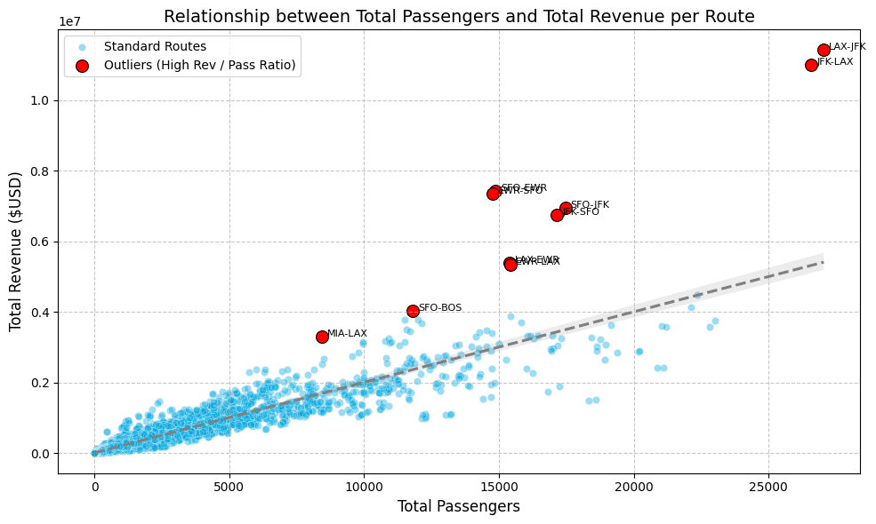

```python
import numpy as np

# Scatter plot of Total Passengers vs Total Revenue
plt.figure(figsize=(10, 6))

# Create the standard scatter plot
sns.scatterplot(data=route_group, x='Total_Passengers', y='Total_Revenue', alpha=0.4, color='#00a8e1', label='Standard Routes')

# Add a regression line to highlight the trend
sns.regplot(data=route_group, x='Total_Passengers', y='Total_Revenue', scatter=False, color='gray', line_kws={"linestyle":"--"})

# Identify outliers: routes with the highest revenue relative to their passenger count
# We calculate the residual (actual revenue - expected revenue based on the trend)
slope, intercept = np.polyfit(route_group['Total_Passengers'], route_group['Total_Revenue'], 1)
route_group['Expected_Revenue'] = slope * route_group['Total_Passengers'] + intercept
route_group['Residual'] = route_group['Total_Revenue'] - route_group['Expected_Revenue']

# Select the top 10 outliers with the highest positive residuals
outliers = route_group.nlargest(10, 'Residual')

# Highlight outliers in red
sns.scatterplot(data=outliers, x='Total_Passengers', y='Total_Revenue', color='red', s=100, edgecolor='black', label='Outliers (High Rev / Pass Ratio)')

# Add text labels for the outliers
for i, row in outliers.iterrows():
    plt.text(row['Total_Passengers'] + 200, row['Total_Revenue'], f"{row['Origin']}-{row['Dest']}", fontsize=8)

# Formatting
plt.title('Relationship between Total Passengers and Total Revenue per Route', fontsize=14)
plt.xlabel('Total Passengers', fontsize=12)
plt.ylabel('Total Revenue ($USD)', fontsize=12)
plt.grid(True, linestyle='--', alpha=0.7)
plt.legend()

plt.tight_layout()
plt.show()
```

## Model 3: New Nonstop Route Revenue Prediction

Unlike Model 1, which predicts the total market revenue for a route, Model 3 aims to predict the revenue generated specifically by a **new nonstop flight** introduced to a route that previously only had connecting options.

First, we need to extract our training samples by finding routes that transitioned from `Nonstop_Exists = 0` to `Nonstop_Exists = 1` across our 6-quarter dataset.

```python
import gc

# 1. Aggregate quarterly data safely
quarterly_stats = []
years_quarters = [(2024, 1), (2024, 2), (2024, 3), (2024, 4), (2025, 1), (2025, 2)]

for y, q in years_quarters:
    print(f"Processing {y} Q{q} for transition analysis...")
    download_and_save_bts(y, q) # Ensure data is downloaded

    market_file = os.path.join(project_path, f'db1b_market_{y}q{q}.parquet')
    coupon_file = os.path.join(project_path, f'db1b_coupon_{y}q{q}.parquet')

    # Load only necessary columns to save RAM
    market_cols = ["ItinID", "MktFare", "Origin", "Dest", "Passengers"]
    coupon_cols = ["ItinID", "Break"]

    df_m = pd.read_parquet(market_file, columns=market_cols)
    df_c = pd.read_parquet(coupon_file, columns=coupon_cols)

    # Determine Break (Nonstop vs Connecting)
    coupon_agg = df_c.groupby('ItinID').size().reset_index(name='Legs')
    coupon_agg['Break'] = (coupon_agg['Legs'] > 1).astype(int)

    # Merge and calculate revenue
    df_merged = df_m.merge(coupon_agg[['ItinID', 'Break']], on="ItinID", how="inner")
    df_merged['Route'] = df_merged['Origin'] + "-" + df_merged['Dest']
    df_merged['EstimatedRevenue'] = df_merged['MktFare'] * df_merged['Passengers']

    # Isolate nonstop revenue
    df_merged['Nonstop_Revenue'] = df_merged.apply(lambda row: row['EstimatedRevenue'] if row['Break'] == 0 else 0, axis=1)

    # Aggregate by Route for this quarter
    route_agg = df_merged.groupby('Route').agg(
        Origin=('Origin', 'first'),
        Dest=('Dest', 'first'),
        Total_Passengers=('Passengers', 'sum'),
        Total_Revenue=('EstimatedRevenue', 'sum'),
        Nonstop_Exists=('Break', lambda x: 1 if 0 in x.values else 0),
        Nonstop_Revenue=('Nonstop_Revenue', 'sum')
    ).reset_index()

    route_agg['Year'] = y
    route_agg['Quarter'] = q
    route_agg['TimePeriod'] = f"{y} Q{q}"

    quarterly_stats.append(route_agg)

    # Free up memory
    del df_m, df_c, coupon_agg, df_merged
    gc.collect()

df_panel = pd.concat(quarterly_stats, ignore_index=True)
print("Finished building panel data!")
```

```
Processing 2024 Q1 for transition analysis...
File ../content/drive/MyDrive/Tulane/DataScience/db1b_market_2024q1.parquet already exists. Skipping download.
File ../content/drive/MyDrive/Tulane/DataScience/db1b_coupon_2024q1.parquet already exists. Skipping download.
Processing 2024 Q2 for transition analysis...
File ../content/drive/MyDrive/Tulane/DataScience/db1b_market_2024q2.parquet already exists. Skipping download.
File ../content/drive/MyDrive/Tulane/DataScience/db1b_coupon_2024q2.parquet already exists. Skipping download.
Processing 2024 Q3 for transition analysis...
File ../content/drive/MyDrive/Tulane/DataScience/db1b_market_2024q3.parquet already exists. Skipping download.
File ../content/drive/MyDrive/Tulane/DataScience/db1b_coupon_2024q3.parquet already exists. Skipping download.
Processing 2024 Q4 for transition analysis...
File ../content/drive/MyDrive/Tulane/DataScience/db1b_market_2024q4.parquet already exists. Skipping download.
File ../content/drive/MyDrive/Tulane/DataScience/db1b_coupon_2024q4.parquet already exists. Skipping download.
Processing 2025 Q1 for transition analysis...
File ../content/drive/MyDrive/Tulane/DataScience/db1b_market_2025q1.parquet already exists. Skipping download.
File ../content/drive/MyDrive/Tulane/DataScience/db1b_coupon_2025q1.parquet already exists. Skipping download.
Processing 2025 Q2 for transition analysis...
File ../content/drive/MyDrive/Tulane/DataScience/db1b_market_2025q2.parquet already exists. Skipping download.
File ../content/drive/MyDrive/Tulane/DataScience/db1b_coupon_2025q2.parquet already exists. Skipping download.
Finished building panel data!
```

```python
# 2. Identify routes that transitioned from Connecting-Only to Nonstop
df_panel = df_panel.sort_values(by=['Route', 'Year', 'Quarter'])

transitions = []

for route, group in df_panel.groupby('Route'):
    if len(group) < 2:
        continue

    group = group.reset_index(drop=True)

    for i in range(1, len(group)):
        # Check if it didn't have a nonstop flight last quarter, but has one this quarter
        if group.loc[i, 'Nonstop_Exists'] == 1 and group.loc[i-1, 'Nonstop_Exists'] == 0:

            pre_demand = group.loc[i-1, 'Total_Passengers']
            post_nonstop_rev = group.loc[i, 'Nonstop_Revenue']

            transitions.append({
                'Route': route,
                'Origin': group.loc[i, 'Origin'],
                'Dest': group.loc[i, 'Dest'],
                'Transition_Period': group.loc[i, 'TimePeriod'],
                'Pre_Demand_Pass': pre_demand,
                'Target_Nonstop_Revenue': post_nonstop_rev
            })
            break # Move to next route after finding the first transition

df_transitions = pd.DataFrame(transitions)
print(f"--- Found {len(df_transitions)} Transition Routes ---")
display(df_transitions.head(10))
```

```
--- Found 3221 Transition Routes ---
```

|  | Route | Origin | Dest | Transition_Period | Pre_Demand_Pass | Target_Nonstop_Revenue |
| --- | --- | --- | --- | --- | --- | --- |
| 0 | ABE-DEN | ABE | DEN | 2025 Q2 | 60.0 | 8270.0 |
| 1 | ABE-MCO | ABE | MCO | 2024 Q2 | 101.0 | 6282.0 |
| 2 | ABQ-ALB | ABQ | ALB | 2024 Q3 | 169.0 | 341.0 |
| 3 | ABQ-BDL | ABQ | BDL | 2024 Q4 | 282.0 | 654.0 |
| 4 | ABQ-BHM | ABQ | BHM | 2024 Q2 | 110.0 | 1252.0 |
| 5 | ABQ-BNA | ABQ | BNA | 2024 Q3 | 677.0 | 3106.0 |
| 6 | ABQ-BOI | ABQ | BOI | 2024 Q4 | 276.0 | 203.0 |
| 7 | ABQ-BUF | ABQ | BUF | 2024 Q4 | 165.0 | 423.0 |
| 8 | ABQ-CID | ABQ | CID | 2024 Q3 | 76.0 | 636.0 |
| 9 | ABQ-CMH | ABQ | CMH | 2024 Q2 | 180.0 | 875.0 |

### Preparing Features for Model 3

We will merge our geographical and proxy climate data into our new transition dataset. We will use a Random Forest model to avoid negative revenue predictions and capture non-linear market dynamics.

```python
from sklearn.ensemble import RandomForestRegressor

# 1. Merge Origin Coordinates
df_transitions = df_transitions.merge(df_airports[['IATA', 'Latitude', 'Longitude']], left_on='Origin', right_on='IATA', how='inner')
df_transitions.rename(columns={'Latitude': 'Orig_Lat', 'Longitude': 'Orig_Lon'}, inplace=True)
df_transitions.drop(columns=['IATA'], inplace=True)

# 2. Merge Destination Coordinates
df_transitions = df_transitions.merge(df_airports[['IATA', 'Latitude', 'Longitude']], left_on='Dest', right_on='IATA', how='inner')
df_transitions.rename(columns={'Latitude': 'Dest_Lat', 'Longitude': 'Dest_Lon'}, inplace=True)
df_transitions.drop(columns=['IATA'], inplace=True)

# 3. Calculate Distance
df_transitions['Distance'] = haversine(df_transitions['Orig_Lat'], df_transitions['Orig_Lon'], df_transitions['Dest_Lat'], df_transitions['Dest_Lon'])

# 4. Map Regions
df_transitions['Orig_Region'] = df_transitions.apply(lambda row: get_region(row['Orig_Lat'], row['Orig_Lon']), axis=1)
df_transitions['Dest_Region'] = df_transitions.apply(lambda row: get_region(row['Dest_Lat'], row['Dest_Lon']), axis=1)

# 5. Proxy Temperatures for Training
df_transitions['Orig_Temp'] = 100 - (df_transitions['Orig_Lat'] * 1.2)
df_transitions['Dest_Temp'] = 100 - (df_transitions['Dest_Lat'] * 1.2)

display(df_transitions.head())
```

|  | Route | Origin | Dest | Transition_Period | Pre_Demand_Pass | Target_Nonstop_Revenue | Orig_Lat | Orig_Lon | Dest_Lat | Dest_Lon | Distance | Orig_Region | Dest_Region | Orig_Temp | Dest_Temp |
| --- | --- | --- | --- | --- | --- | --- | --- | --- | --- | --- | --- | --- | --- | --- | --- |
| 0 | ABE-DEN | ABE | DEN | 2025 Q2 | 60.0 | 8270.0 | 40.652100 | -75.440804 | 39.861698 | -104.672997 | 1535.252761 | Northeast | West | 51.217480 | 52.165962 |
| 1 | ABE-MCO | ABE | MCO | 2024 Q2 | 101.0 | 6282.0 | 40.652100 | -75.440804 | 28.429399 | -81.308998 | 907.576664 | Northeast | South | 51.217480 | 65.884721 |
| 2 | ABQ-ALB | ABQ | ALB | 2024 Q3 | 169.0 | 341.0 | 35.040199 | -106.609001 | 42.748299 | -73.801697 | 1829.837924 | West | Northeast | 57.951761 | 48.702042 |
| 3 | ABQ-BDL | ABQ | BDL | 2024 Q4 | 282.0 | 654.0 | 35.040199 | -106.609001 | 41.938900 | -72.683197 | 1882.280403 | West | Northeast | 57.951761 | 49.673320 |
| 4 | ABQ-BHM | ABQ | BHM | 2024 Q2 | 110.0 | 1252.0 | 35.040199 | -106.609001 | 33.562901 | -86.753502 | 1136.006045 | West | South | 57.951761 | 59.724519 |

### Training Model 3

```python
# Prepare Features (X) and Target (y)
features_m3 = ['Pre_Demand_Pass', 'Orig_Temp', 'Dest_Temp', 'Distance', 'Orig_Region', 'Dest_Region']
X3 = df_transitions[features_m3]
y3 = df_transitions['Target_Nonstop_Revenue']

# Preprocessing
preprocessor_m3 = ColumnTransformer(
    transformers=[
        ('cat', categorical_transformer, categorical_features)
    ], remainder='passthrough')

# Create Pipeline for Model 3 (Random Forest)
rf_pipeline_m3 = Pipeline(steps=[
    ('preprocessor', preprocessor_m3),
    ('regressor', RandomForestRegressor(n_estimators=100, random_state=42))
])

# Train-test split
X_train3, X_test3, y_train3, y_test3 = train_test_split(X3, y3, test_size=0.2, random_state=42)

# Train model
rf_pipeline_m3.fit(X_train3, y_train3)

# Evaluate model
y_pred3 = rf_pipeline_m3.predict(X_test3)
print("--- Model 3: New Nonstop Route Revenue Performance ---")
print(f"RMSE: ${np.sqrt(mean_squared_error(y_test3, y_pred3)):,.2f}")
print(f"R^2 Score: {r2_score(y_test3, y_pred3):.4f}")
```

```
--- Model 3: New Nonstop Route Revenue Performance ---
RMSE: $8,261.09
R^2 Score: 0.1144
```

### Model 3 Prediction Function

Let's build a function to feed live data into our Random Forest model and predict the revenue for introducing a new nonstop flight.

```python
def predict_new_nonstop_revenue(origin_code, dest_code, quarter, year=2024):
    """
    Predicts the estimated revenue generated by introducing a NEW nonstop flight
    using the trained Random Forest model (Model 3).
    """
    # 1. Get airport info
    orig_info = df_airports[df_airports['IATA'] == origin_code]
    dest_info = df_airports[df_airports['IATA'] == dest_code]

    if orig_info.empty or dest_info.empty:
        return "Error: Airport code not found in OpenFlights dataset."

    orig_lat, orig_lon = orig_info.iloc[0]['Latitude'], orig_info.iloc[0]['Longitude']
    dest_lat, dest_lon = dest_info.iloc[0]['Latitude'], dest_info.iloc[0]['Longitude']

    # 2. Fetch actual weather
    print(f"Fetching weather for {origin_code} and {dest_code} for {year} Q{quarter}...")
    orig_temp = get_quarterly_temperature(orig_lat, orig_lon, year, quarter)
    dest_temp = get_quarterly_temperature(dest_lat, dest_lon, year, quarter)

    # Fallback to proxy if API fails
    if orig_temp is None: orig_temp = 100 - (orig_lat * 1.2)
    if dest_temp is None: dest_temp = 100 - (dest_lat * 1.2)

    # 3. Calculate distance
    dist = haversine(orig_lat, orig_lon, dest_lat, dest_lon)

    # 4. Get Regions
    orig_region = get_region(orig_lat, orig_lon)
    dest_region = get_region(dest_lat, dest_lon)

    # 5. Get Pre-existing Demand
    route_data = route_group[(route_group['Origin'] == origin_code) & (route_group['Dest'] == dest_code)]
    if not route_data.empty:
        pre_demand = route_data.iloc[0]['Total_Passengers']
    else:
        pre_demand = 0

    # 6. Create feature dataframe
    feature_df = pd.DataFrame([{
        'Pre_Demand_Pass': pre_demand,
        'Orig_Temp': orig_temp,
        'Dest_Temp': dest_temp,
        'Distance': dist,
        'Orig_Region': orig_region,
        'Dest_Region': dest_region
    }])

    # 7. Predict
    prediction = rf_pipeline_m3.predict(feature_df)[0]

    print("\n" + "="*40)
    print(f"Model 3 Prediction: {origin_code} -> {dest_code} (Q{quarter})")
    print("-"*40)
    print(f"Distance: {dist:.1f} miles")
    print(f"Origin ({orig_region}): {orig_temp:.1f}°F")
    print(f"Destination ({dest_region}): {dest_temp:.1f}°F")
    print(f"Pre-existing Connecting Demand: {pre_demand:,.0f} passengers")
    print("="*40)
    print(f"Predicted New Nonstop Revenue: ${prediction:,.2f}")
    print("="*40)

    return prediction
```

```python
# Test it on MSY-TPA in Q1
predict_new_nonstop_revenue('MSY', 'TPA', 1);
```

```
Fetching weather for MSY and TPA for 2024 Q1...

========================================
Model 3 Prediction: MSY -> TPA (Q1)
----------------------------------------
Distance: 487.1 miles
Origin (South): 58.8°F
Destination (South): 63.5°F
Pre-existing Connecting Demand: 2,890 passengers
========================================
Predicted New Nonstop Revenue: $12,522.58
========================================
```

```
np.float64(12522.58)
```

## Identifying Top New Route Opportunities

Let's apply Model 3 to all existing routes that currently only have connecting flights to find the biggest opportunities for a low-cost carrier to introduce a nonstop flight.

```python
# 1. Filter for routes with NO nonstop competition
potential_routes = route_group[route_group['Nonstop_Exists'] == 0].copy()

# 2. Rename Total_Passengers to Pre_Demand_Pass to match Model 3's expected features
potential_routes.rename(columns={'Total_Passengers': 'Pre_Demand_Pass'}, inplace=True)

# 3. Select the exact features used by Model 3
X_potential = potential_routes[['Pre_Demand_Pass', 'Orig_Temp', 'Dest_Temp', 'Distance', 'Orig_Region', 'Dest_Region']]

# 4. Predict the new nonstop revenue for all these routes at once
potential_routes['Predicted_New_Nonstop_Revenue'] = rf_pipeline_m3.predict(X_potential)

# 5. Sort the results to find the highest predicted revenue
top_new_routes = potential_routes.sort_values(by='Predicted_New_Nonstop_Revenue', ascending=False)

# 6. Display the Top 10 recommendations
display_cols = ['Origin', 'Dest', 'Pre_Demand_Pass', 'Distance', 'Orig_Region', 'Dest_Region', 'Predicted_New_Nonstop_Revenue']
print("--- Top 10 Recommended New Nonstop Routes ---")
display(top_new_routes[display_cols].head(10))
```

```
--- Top 10 Recommended New Nonstop Routes ---
```

|  | Origin | Dest | Pre_Demand_Pass | Distance | Orig_Region | Dest_Region | Predicted_New_Nonstop_Revenue |
| --- | --- | --- | --- | --- | --- | --- | --- |
| 32339 | JFK | SMF | 681.0 | 2514.915815 | Northeast | West | 73475.05 |
| 32285 | JFK | ONT | 409.0 | 2424.063706 | Northeast | West | 69910.10 |
| 56557 | SFO | ANC | 284.0 | 2015.695378 | West | West | 67985.36 |
| 45232 | ONT | JFK | 377.0 | 2424.063706 | West | Northeast | 64763.82 |
| 59141 | SMF | JFK | 629.0 | 2514.915815 | West | Northeast | 61818.00 |
| 32233 | JFK | KOA | 359.0 | 4945.362992 | Northeast | West | 53775.01 |
| 57823 | SJC | ANC | 131.0 | 2042.660519 | West | West | 53252.88 |
| 7934 | BOS | SJC | 424.0 | 2682.283430 | Northeast | West | 52885.18 |
| 2780 | ANC | STT | 4.0 | 4948.445151 | West | South | 52628.18 |
| 56657 | SFO | FAI | 316.0 | 2145.809763 | West | West | 51511.44 |

## Top Predictions Have Already Been Copied by Airlines!

Several of our top predictions have already been implemented by JetBlue, with service on JFK-SMF, JFK-ONT, and SFO-ANC on Alaska and Delta.

## Limitations

Our model is inherently capped in how useful its insights are. It fails to account for variables that turn a high-revenue route into a highly profitable route.

This is impossible to generalize across different airlines, as every airline has a unique business, with different fleets, hub airports, and strategies to extract revenue from passengers. While a route may be highly profitable for Breeze Airways because it flies through one of their hub airports and their aircraft are perfect for meeting demand, Frontier could be highly unprofitable on the same exact route.

These routes serve as a starting point. It is up to individual airlines to decide if they are fit for themselves.

```python
!jupyter nbconvert --to html "/content/drive/MyDrive/Tulane/DataScience/Low Cost Carrier Flight Opportunities.ipynb" --output index.html
```

```
[NbConvertApp] Converting notebook /content/drive/MyDrive/Tulane/DataScience/Low Cost Carrier Flight Opportunities.ipynb to html
[NbConvertApp] WARNING | Alternative text is missing on 8 image(s).
[NbConvertApp] Writing 1414710 bytes to /content/drive/MyDrive/Tulane/DataScience/index.html
```